# Lab 4

Tessa Mendoza and Becca Barrick

10/6/2020

```r
library(readxl)
library(tidyverse)
```

```r
defense <- read_excel('cyclonesFootball2019.xlsx', sheet = "Defensive")
offense <- read_excel('cyclonesFootball2019.xlsx', sheet = "Offensive")
info <- read_excel('cyclonesFootball2019.xlsx', sheet = "Biography")
```

## Cleaning the Data

```r
defClean <- defense %>%
  mutate(Name = factor(Name)) %>%
  rename(Opponent = Opponent_Opponent) %>%
  mutate(Opponent = factor(Opponent)) %>%
  mutate_if(is.character, as.numeric)

offClean <- offense %>%
  mutate(Name = factor(Name)) %>%
  rename(Opponent = Opponent_Opponent) %>%
  mutate(Opponent = factor(Opponent)) %>%
  mutate_if(is.character, as.numeric)

bioClean <- info %>%
  mutate(Name = factor(Name)) %>%
  separate(Height, c('Height_ft', 'Height_in'), sep ="-") %>%
  mutate(Weight = as.numeric(Weight)) %>%
  mutate(Height_ft = as.numeric(Height_ft)) %>%
  mutate(Height_in = as.numeric(Height_in))
```

```r
defClean
```

```
## # A tibble: 502 x 11
##    Name  Opponent Tackles_Solo Tackles_ASST Tackles_TFL Tackles_Sack Turnover_FF
##    <fct> <fct>           <dbl>        <dbl>       <dbl>        <dbl>       <dbl>
##  1 Whit… UNI                 4            4           0            0           0
##  2 Whit… Iowa                4            7           0            0           0
##  3 Whit… ULM                 3            5           0            0           0
##  4 Whit… Baylor              4            2           0            0           0
##  5 Whit… TCU                 3            2           1            0           0
##  6 Whit… West Vi…            1            1           0            0           0
##  7 Whit… Texas T…            7            1           0            0           0
##  8 Whit… Oklahom…            3            2           0            0           0
##  9 Whit… Oklahoma            6            1           1            0           0
## 10 Whit… Texas               5            5           1            1           0
## # … with 492 more rows, and 4 more variables: Turnover_FR <dbl>,
## #   Turnover_INT <dbl>, Pass_QBH <dbl>, Pass_PB <dbl>
```

```r
offClean
```

```
## # A tibble: 195 x 12
##    Name  Opponent Rushing_ATT Rushing_YDS Rushing_TD Receiving_REC Receiving_YDS
##    <fct> <fct>          <dbl>       <dbl>      <dbl>         <dbl>         <dbl>
##  1 Aker… UNI                0           0          0             1            21
##  2 Aker… Iowa               0           0          0             0             0
##  3 Aker… ULM                1           8          0             0             0
##  4 Aker… Baylor             0           0          0             0             0
##  5 Aker… TCU                0           0          0             1            32
##  6 Aker… West Vi…           0           0          0             0             0
##  7 Aker… Texas T…           0           0          0             0             0
##  8 Aker… Oklahom…           0           0          0             4            39
##  9 Aker… Oklahoma           0           0          0             0             0
## 10 Aker… Texas              0           0          0             1             7
## # … with 185 more rows, and 5 more variables: Receiving_TD <dbl>,
## #   `Passing_CMP-ATT` <dbl>, Passing_YDS <dbl>, Passing_TD <dbl>,
## #   Passing_INT <dbl>
```

```r
bioClean
```

```
## # A tibble: 105 x 8
##    Name      Position   Height_ft Height_in Weight Class   Hometown   Highschool
##    <fct>     <chr>          <dbl>     <dbl>  <dbl> <chr>   <chr>      <chr>
##  1 Akers, L… Wide Rece…         6         0    188 Redshi… Cedar Rap… Washington
##  2 Allen, C… Tight End          6         7    245 Redshi… Nixa, Mo.  Nixa
##  3 Anderson… Wide Rece…         6         5    204 Redshi… Seffner, … Armwood
##  4 Assalley… Placekick…         6         0    195 Redshi… Napervill… Central
##  5 Azunna, … Defensive…         6         0    190 Redshi… Grand Pra… Lake Ridge
##  6 Bailey, … Defensive…         6         3    235 Redshi… Clarksdal… Clarksdale
##  7 Bailey, … Defensive…         6         2    255 Redshi… Jacksonvi… Raines
##  8 Bailey, … Defensive…         6         2    285 Redshi… Jacksonvi… Raines
##  9 Bankston… Defensive…         6         0    300 Junior  Woodstock… Woodstock
## 10 Bouman, … Quarterba…         6         6    215 Freshm… Buffalo, … Buffalo
## # … with 95 more rows
```

## Tidying the Data

```r
defClean <- defClean %>%
  pivot_longer(Tackles_Solo:Pass_PB, names_to = 'stat')
defClean
```

```
## # A tibble: 4,518 x 4
##    Name            Opponent stat         value
##    <fct>           <fct>    <chr>        <dbl>
##  1 White, Lawrence UNI      Tackles_Solo     4
##  2 White, Lawrence UNI      Tackles_ASST     4
##  3 White, Lawrence UNI      Tackles_TFL      0
##  4 White, Lawrence UNI      Tackles_Sack     0
##  5 White, Lawrence UNI      Turnover_FF      0
##  6 White, Lawrence UNI      Turnover_FR      0
##  7 White, Lawrence UNI      Turnover_INT     0
##  8 White, Lawrence UNI      Pass_QBH         1
##  9 White, Lawrence UNI      Pass_PB          1
## 10 White, Lawrence Iowa     Tackles_Solo     4
## # … with 4,508 more rows
```

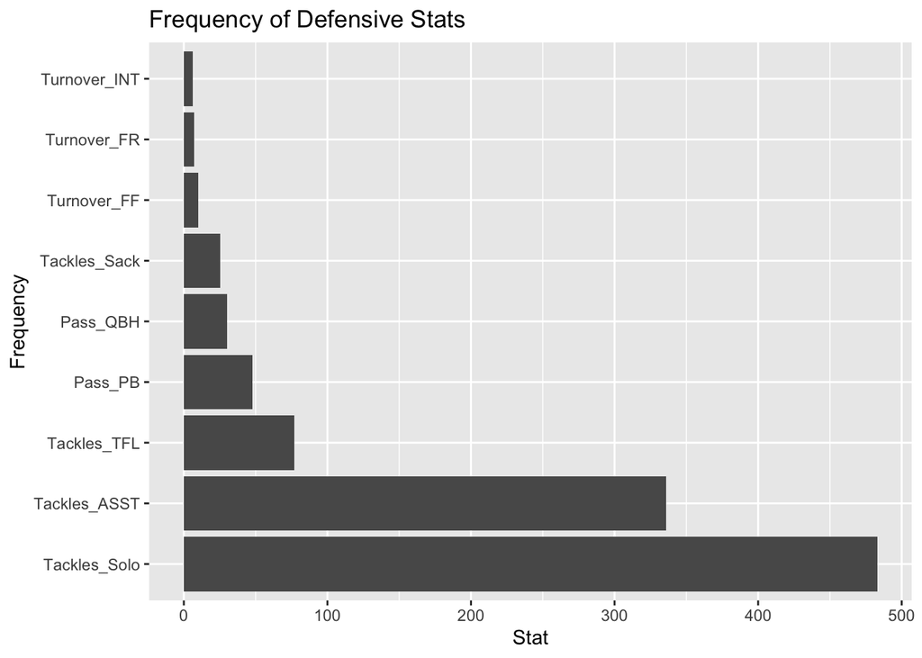

```r
ggplot(defClean, aes(x = reorder(stat, -value), y = value)) + geom_bar(stat = 'identity') + coord_flip() + labs(x = 'Frequency', y = 'Stat', title = 'Frequency of Defensive Stats')
```

```r
def2 <- defClean %>%
  group_by(stat) %>%
  summarise(sum = sum(value)) %>%
  arrange(sum)
```

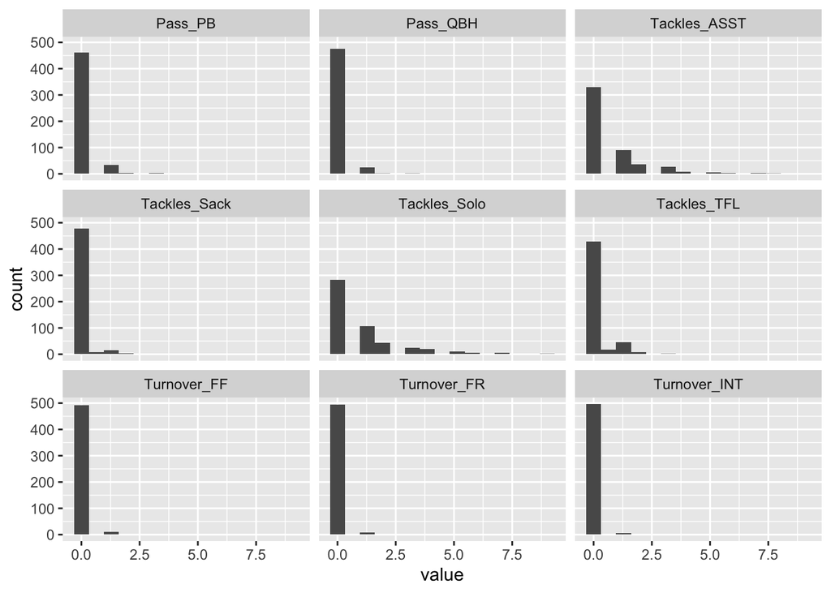

```r
ggplot(defClean, aes(x=value)) + geom_histogram(bins=15) + facet_wrap(~stat)
```

```r
def2
```

```
## # A tibble: 9 x 2
##   stat           sum
##   <chr>        <dbl>
## 1 Turnover_INT   6
## 2 Turnover_FR    7
## 3 Turnover_FF   10
## 4 Tackles_Sack  25.5
## 5 Pass_QBH      30
## 6 Pass_PB       48
## 7 Tackles_TFL   77
## 8 Tackles_ASST 336
## 9 Tackles_Solo 483
```

Naturally, there is a right-skewed distribution of each of the defensive statistics, as most players have 0 recorded statistics. The most variable distribution is solo tackles, where as number of interceptions and turnovers for a single player is not high. As shown in the table, inerceptions, forced fumbles, and recovered fumbles are the most rare defensive skills.

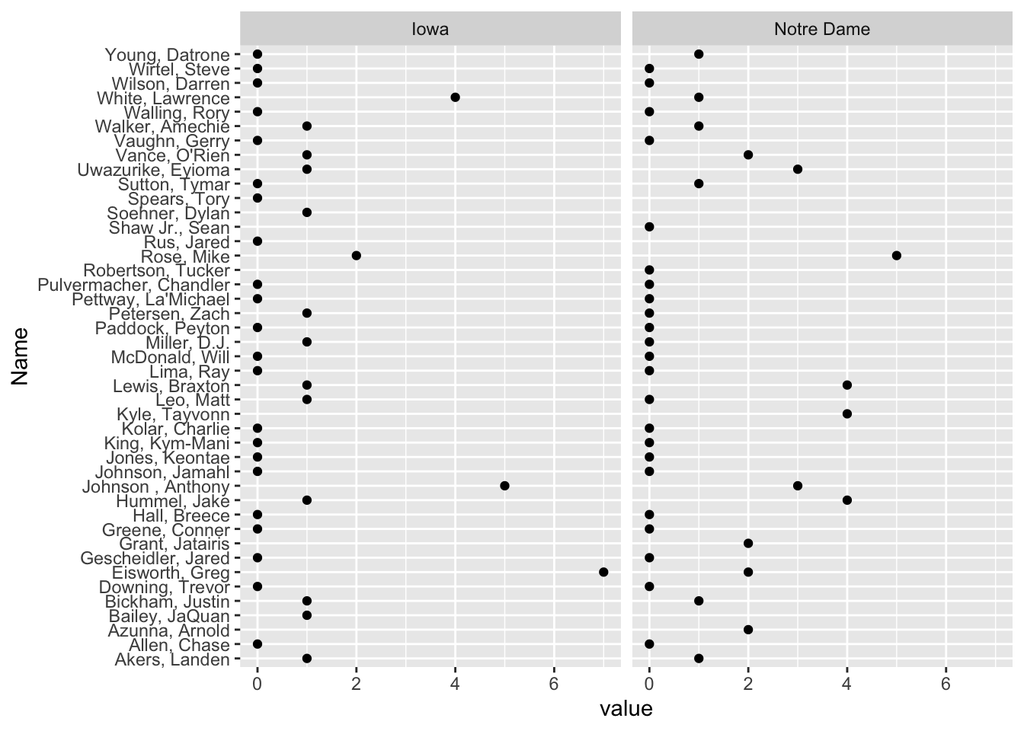

```r
def3 <- defClean %>%
  group_by(Opponent) %>%
  filter(Opponent == "Iowa" | Opponent == "Notre Dame") %>%
  filter(stat == "Tackles_Solo")
ggplot(def3, aes(x = Name, y = value)) + geom_point() + coord_flip() + facet_wrap(~Opponent)
```

Based on this data, Iowa State had a better defensive performance against Notre Dame compared to Iowa. As you can see, many more solo tackles were made against Notre Dame than against Iowa. Mike Rose led the team with 5 solo tackles against ND, and Greg Eisworth led the team with 7 against Iowa. However, against Iowa, only two other players had three or more solo tackles. This is less than against Notre Dame, where six players had 3+ tackles. 4)

```r
bioClean <- bioClean %>%
  separate(Hometown, c('Hometown_City', 'Hometown_State'), sep =", ")
head(bioClean)
```

```
## # A tibble: 6 x 9
##   Name  Position Height_ft Height_in Weight Class Hometown_City Hometown_State
##   <fct> <chr>        <dbl>     <dbl>  <dbl> <chr> <chr>         <chr>
## 1 Aker… Wide Re…         6         0    188 Reds… Cedar Rapids  Iowa
## 2 Alle… Tight E…         6         7    245 Reds… Nixa          Mo.
## 3 Ande… Wide Re…         6         5    204 Reds… Seffner       Fla.
## 4 Assa… Placeki…         6         0    195 Reds… Naperville    Ill.
## 5 Azun… Defensi…         6         0    190 Reds… Grand Prairie Texas
## 6 Bail… Defensi…         6         3    235 Reds… Clarksdale    Miss.
## # … with 1 more variable: Highschool <chr>
```

```r
hometown <- bioClean %>%
  group_by(Hometown_State) %>%
  summarize(count = n()) %>%
  arrange(desc(count))
hometown
```

```
## # A tibble: 19 x 2
##    Hometown_State count
##    <chr>          <int>
##  1 Iowa              35
##  2 Fla.              10
##  3 Ohio               7
##  4 Mo.                6
##  5 Texas              6
##  6 Wis.               6
##  7 Ill.               5
##  8 Ariz.              4
##  9 Ga.                4
## 10 Mich.              4
## 11 Minn.              4
## 12 Calif.             3
## 13 Kan.               3
## 14 Okla.              2
## 15 S.D.               2
## 16 Ark.               1
## 17 Australia          1
## 18 Miss.              1
## 19 Pa.                1
```

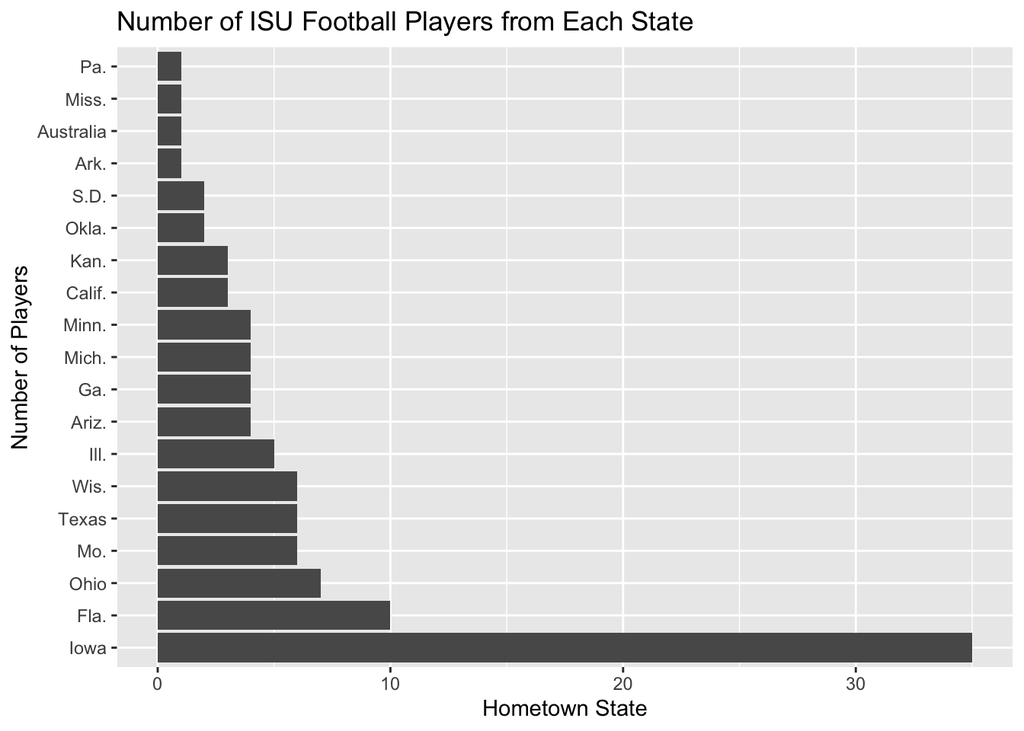

```r
ggplot(hometown, aes(x = reorder(Hometown_State, -count), y = count)) + geom_bar(stat = 'identity') + coord_flip() + labs(x = 'Number of Players', y = 'Hometown State', title = 'Number of ISU Football Players from Each State')
```

By far, the largest number of players come from Iowa. Florida and Ohio are the second and third most common home state. Knowing Iowa State’s football program, this makes sense - a lot of football talent comes from Florida, and the coaching staff at ISU came from Ohio!

## Joining Data Frames

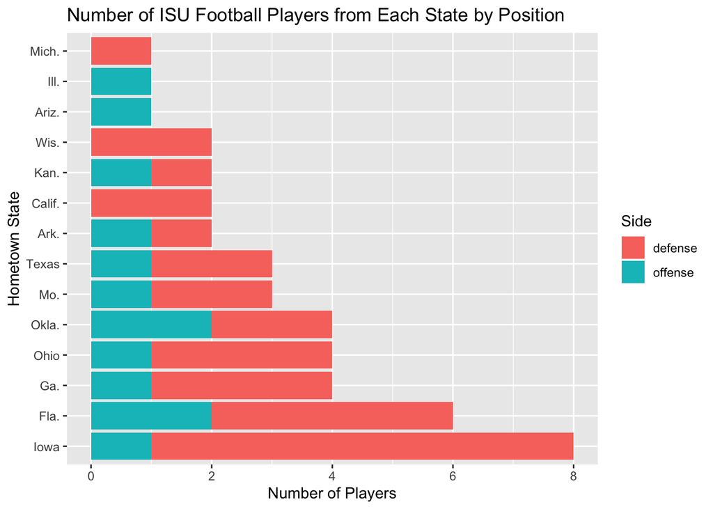

```r
offClean <- offClean %>%
  pivot_longer(Rushing_ATT:Passing_INT, names_to = 'stat')

hometownD <- defClean %>%
  distinct(Name) %>%
  left_join(bioClean %>% select(Name, Hometown_State), by = c(Name = 'Name')) %>%
  mutate(Side = "defense")

hometownO <- offClean %>%
  distinct(Name) %>%
  left_join(bioClean %>% select(Name, Hometown_State), by = c(Name = 'Name')) %>%
  mutate(Side = "offense")

hometown2 <- hometownD %>%
  full_join(hometownO, by = c(Name = "Name", Hometown_State = "Hometown_State", Side = "Side")) %>%
  filter(!is.na(Hometown_State))

ggplot(hometown2, aes(x = forcats::fct_infreq(Hometown_State), subgroup = Side, fill = Side)) + geom_bar(position = "stack") + coord_flip() + labs(x = 'Hometown State', y = 'Number of Players', title = 'Number of ISU Football Players from Each State by Position')
```

Again, it is clear that most of the players come from Iowa (on defense), and most come from Oklahoma or Florida on offense. Note: this sample was slightly affected by an issue where the biographical information was provided for the 2020 roster, not the 2019 roster. Therefore, several of the senior players from last season did not have hometown information in the new ‘bioClean’ dataset, so their information was removed. Also, players who played on both sides of the ball (typically due to special teams) were considered defensive.

```r
brock <- offClean %>%
  filter(Name == "Purdy, Brock") %>%
  filter(stat == "Passing_YDS" | stat == "Rushing_YDS") %>%
  group_by(stat, Opponent) %>%
  summarize(value)
```

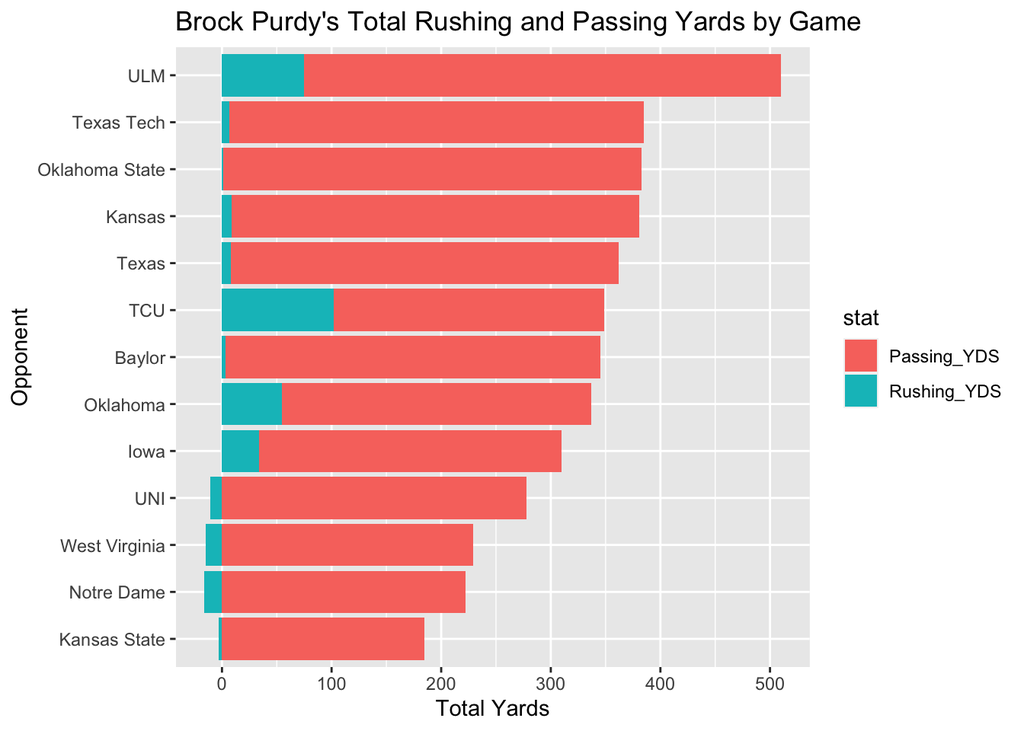

```r
ggplot(brock, aes(x = reorder(Opponent, value), y = value, fill = stat)) + geom_bar(stat = 'identity', position = 'stack') + coord_flip() + labs(x = "Opponent", y = "Total Yards", title = "Brock Purdy's Total Rushing and Passing Yards by Game")
```

In the 2019 season, Iowa State had wins against UNI (overtime), ULM, TCU, West Virginia, Texas Tech, Texas, and Kansas. Their losses were to Iowa, Baylor, Oklahoma State, Oklahoma, Kansas State, and Notre Dame. As we can see, in Brock Purdy’s top six games with the most total yards (both passing and rushing yards), Iowa State had only one loss - in a one-touchdown defeat late against Oklahoma State. In addition, 5 of Iowa State’s 6 losses occurred in Purdy’s games with lowest total yards of offense. From this, we can see that Brock Purdy’s performance, specifically in passing and rushing yards, significantly affects the outcome of the game.

```r
brock2 <- offClean %>%
  filter(Name == "Purdy, Brock") %>%
  filter(stat == "Passing_TD" | stat == "Passing_INT") %>%
  group_by(stat, Opponent) %>%
  summarize(value)
brock2
```

```
## # A tibble: 26 x 3
## # Groups:   stat [2]
##    stat        Opponent       value
##    <chr>       <fct>          <dbl>
##  1 Passing_INT Baylor             1
##  2 Passing_INT Iowa               0
##  3 Passing_INT Kansas             1
##  4 Passing_INT Kansas State       0
##  5 Passing_INT Notre Dame         0
##  6 Passing_INT Oklahoma           0
##  7 Passing_INT Oklahoma State     3
##  8 Passing_INT TCU                0
##  9 Passing_INT Texas              1
## 10 Passing_INT Texas Tech         1
## # … with 16 more rows
```

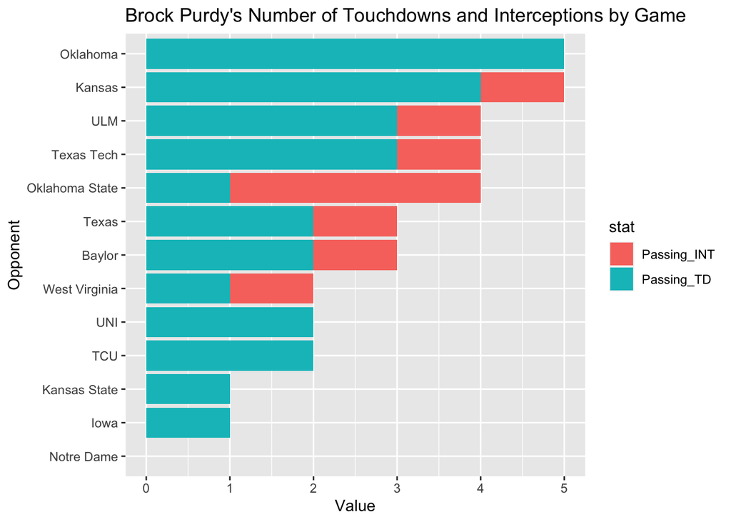

```r
ggplot(brock2, aes(x = reorder(Opponent, value), y = value, fill = stat)) + geom_bar(stat = 'identity', position = 'stack') + coord_flip() + labs(x = "Opponent", y = "Value", title = "Brock Purdy's Number of Touchdowns and Interceptions by Game")
```

Purdy’s performance when it comes to passing touchdown and passing interceptions stats obviously impact the team as well. In the games against Kansas, Louisiana Monroe, and Texas Purdy was able to execute at least 2 touchdown passes that led to a Cyclone win. One outlier was a game where Purdy threw 5 touchdown passes but the Cylclones ended up losing a high scoring game against Oklahoma. On the opposite end of the spectrum, Purdy throwing intercepted passes will lead to a struggle for the cyclones. In a game against Oklahoma State, Purdy threw 3 intercepted passes and the Cylones ended up losing that game.

```r
defense18 <- read_excel('/Users/tmendoza/DS 202/ds202_lab4/cyclonesFootball2018.xlsx', sheet = "Defensive")
offense18 <- read_excel('/Users/tmendoza/DS 202/ds202_lab4/cyclonesFootball2018.xlsx', sheet = "Offensive")

def18 <- defense18 %>%
  mutate(Name = factor(Name)) %>%
  rename(Opponent = Opponent_Opponent) %>%
  mutate(Opponent = factor(Opponent)) %>%
  mutate_if(is.character, as.numeric) %>%
  pivot_wider(Name:Turnover_FR, names_from = Opponent)

solo18 <- aggregate(Tackles_Solo ~ Name, data = def18, FUN = sum)
sacks18 <- aggregate(Tackles_Sack ~ Name, data = def18, FUN = sum)

def19 <- defense %>%
mutate(Name = factor(Name)) %>%
rename(Opponent = Opponent_Opponent) %>%
mutate(Opponent = factor(Opponent)) %>%
mutate_if(is.character, as.numeric) %>%
pivot_wider(Name:Turnover_FR, names_from = Opponent)

solo19 <- aggregate(Tackles_Solo ~ Name, data = def19, FUN = sum)
sacks19 <- aggregate(Tackles_Sack ~ Name, data = def19, FUN = sum)

improveD <- solo18 %>%
  full_join(sacks18, by = c(Name = 'Name')) %>%
  inner_join(solo19, by = c(Name = "Name")) %>%
  full_join(sacks19, by = c(Name = 'Name')) %>%
  rename(solo18 = Tackles_Solo.x, sacks18 = Tackles_Sack.x,
         solo19 = Tackles_Solo.y, sacks19 = Tackles_Sack.y) %>%
  group_by(Name) %>%
  filter(solo19 > solo18 && sacks19 > sacks18)
improveD
```

```
## # A tibble: 7 x 5
## # Groups:   Name [7]
##   Name              solo18 sacks18 solo19 sacks19
##   <fct>              <dbl>   <dbl>  <dbl>   <dbl>
## 1 Azunna, Arnold         7     0       13     1
## 2 Johnson , Anthony     22     0       47     2
## 3 McDonald, Will         2     1        7     5
## 4 Petersen, Zach         1     0       21     2
## 5 Rose, Mike            35     1.5     39     3.5
## 6 Uwazurike, Eyioma     12     1       18     1.5
## 7 Vance, O'Rien         13     1.5     34     6.5
```

To analyze player improvements between 2018 and 2019, I chose to study defensive players and determined their performance based on solo tackles and sacks. Specifically, solo tackles represents a player’s ability to wrap up a defender and make a standalone play. This is especially critical for defensive backs and requires sound fundamental tackling ability. On the other hand, sacks represent a more explosive play and is more common among defensive linemen. Therefore, these combined stats hopefully represent the common and uncommon plays for each position on the defense. With that in mind, I filtered out players who had a higher number of solo tackles AND sacks between 2018 and 2019. 7 players made this list: Azunna, Johnson, McDonald, Petersen, Rose, Uwazurike, and Vance.

```r
off18 <- offense18 %>%
  mutate(Name = factor(Name)) %>%
  rename(Opponent = Opponent_Opponent) %>%
  mutate(Opponent = factor(Opponent)) %>%
  mutate_if(is.character, as.numeric) %>%
  pivot_wider(Name:Receiving_YDS, names_from = Opponent)
YDS18 <- aggregate(Receiving_YDS ~ Name, data = off18, FUN = sum)

off19 <- offense %>%
  mutate(Name = factor(Name)) %>%
  rename(Opponent = Opponent_Opponent) %>%
  mutate(Opponent = factor(Opponent)) %>%
  mutate_if(is.character, as.numeric) %>%
  pivot_wider(Name:Receiving_YDS, names_from = Opponent)
YDS19 <- aggregate(Receiving_YDS ~ Name, data = off19, FUN = sum)

progress <- YDS18 %>%
  inner_join(YDS19, by = c(Name = "Name")) %>%
  rename(YDS18 = Receiving_YDS.x,
         YDS19 = Receiving_YDS.y) %>%
  group_by(Name) %>%
  filter(YDS19 > YDS18)
progress
```

```
## # A tibble: 5 x 3
## # Groups:   Name [5]
##   Name             YDS18 YDS19
##   <fct>            <dbl> <dbl>
## 1 Allen, Chase        84   145
## 2 Jones, Deshaunte   366   877
## 3 Kolar, Charlie     134   697
## 4 Lang, Johnnie       30    54
## 5 Milton, Tarique    417   722
```